# Homework 5-Complete

RMI 4226 Risk and Insurance Data Analytics – Spring 2025

Objective: This exercise serves the purpose of helping student using simple linear regression models.

1. Import the `medical_insurance_expense.csv` data and remove the duplicated observations, create dummy variables for character variables, and save it “medical_data”.

```r
library(CSTools)
medical_dataset <- read.csv("medical_insurance_expense-1.csv")

library(dplyr)
medical_dataset <- medical_dataset %>% distinct()

medical_data <- medical_dataset %>%
  mutate(
    sex = as.factor(sex),
    smoker = as.factor(smoker),
    region = as.factor(region))
```

2. Find the number of observations (N), mean, standard deviation,min, quartiles and max for all numerical/integer variables: age, bmi,children, charges, and the dummy variables created in question 1. Save it as a data frame called summary_statistics.

```r
summary_statistics <- medical_dataset %>%
  select(age, bmi, children, charges, starts_with("sex"),
         starts_with("smoker"), starts_with("region")) %>%
  summarise(list(
    Q1 = ~quantile(., 0.25),
    Median = ~median(.),
    Q3 = ~quantile(., 0.75),
    Max = ~max(.),
    N = ~length(.),
    Mean = ~mean(.),
    SD = ~sd(.),
    Min = ~min(.)
  ))
```

3. Split the medical_data into training and test data sets with a 70-30 split and save them as train_strat and test_strat. Set your seed as 123. When split the data, please make sure each data set have the same proportion of smoker versus non-smoker. Run a simple linear regression model using train_strat and save it as “model_SL” and summary the output.

$$charges = \beta_0 + \beta_1 \times bmi + \varepsilon$$

```r
library(caret)
set.seed(123)

train_index <- createDataPartition(medical_data$smoker,
                                   p = 0.7,
                                   list = FALSE)

train_strat <- medical_data[train_index, ]
test_strat  <- medical_data[-train_index, ]

model_SL <- lm(charges ~ bmi, data = train_strat)
summary(model_SL)
```

```
Call:
lm(formula = charges ~ bmi, data = train_strat)

Residuals:
   Min     1Q Median     3Q    Max
-18063  -7999  -3799   4437  49574

Coefficients:
            Estimate Std. Error t value Pr(>|t|)
(Intercept)   1671.8     2021.6   0.827    0.408
bmi            373.7       64.4   5.804 8.88e-09 ***
---
Signif. codes:  0 '***' 0.001 '**' 0.01 '*' 0.05 '.' 0.1 ' ' 1

Residual standard error: 11980 on 935 degrees of freedom
Multiple R-squared:  0.03477,   Adjusted R-squared:  0.03374
F-statistic: 33.68 on 1 and 935 DF,  p-value: 8.884e-09
```

4. Plot the bmi and charges, and the fitted line with 95% confidence intervals.

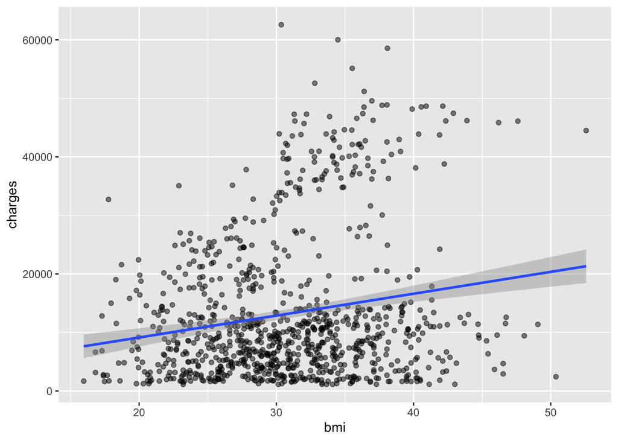

```r
ggplot(train_strat, aes(x = bmi, y = charges)) +
  geom_point(alpha = 0.5) +
  geom_smooth(method = "lm", level = 0.95)
```

5. Can you write down the estimated linear regression equation? How do you interpret the parameters and there statistics, as well as the overall model evaluation.

```r
summary(model_SL)
```

```
Call:
lm(formula = charges ~ bmi, data = train_strat)

Residuals:
   Min     1Q Median     3Q    Max
-18063  -7999  -3799   4437  49574

Coefficients:
            Estimate Std. Error t value Pr(>|t|)
(Intercept)   1671.8     2021.6   0.827    0.408
bmi            373.7       64.4   5.804 8.88e-09 ***
---
Signif. codes:  0 '***' 0.001 '**' 0.01 '*' 0.05 '.' 0.1 ' ' 1

Residual standard error: 11980 on 935 degrees of freedom
Multiple R-squared:  0.03477,   Adjusted R-squared:  0.03374
F-statistic: 33.68 on 1 and 935 DF,  p-value: 8.884e-09
```

Linear Regression Equation- Charges = 1671.8 + 373.7(BMI), this model is not a good indicator as thr Rsquared value is .o3374, which is extremely low.

6. To test the hypothesis that medical insurance charges is positively associated with policyholder’s bmi. Can you justify whether the training data support his hypothesis and why.

The training module doesn’t justify the null hypothesis, as the p value is extremely low. THis means that the values are corelated in some way.

7. Find the confidence interval for model parameters at 95% confidence level. ($\hat{\beta_1} \pm 2*SE$)

```r
confint(model_SL, level = 0.95)
```

```
                 2.5 %   97.5 %
(Intercept) -2295.5624 5639.258
bmi           247.3604  500.127
```

8. Check the histogram of residuals, and how to you evaluate your data.

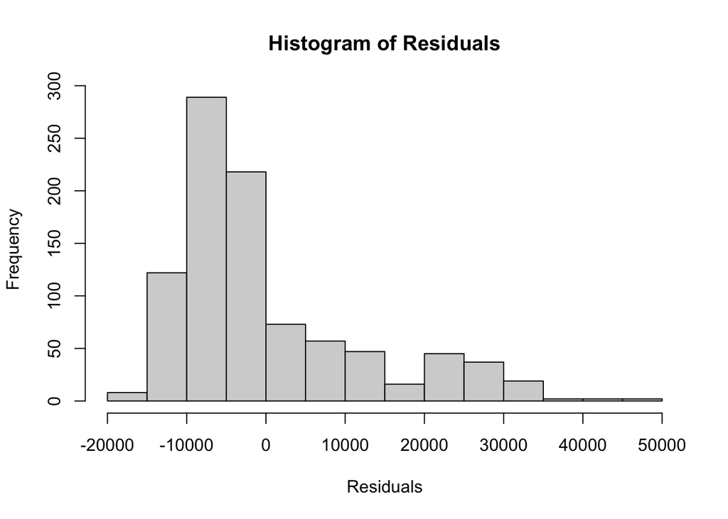

```r
residuals_SL <- residuals(model_SL)

hist(residuals_SL,
     main = "Histogram of Residuals",
     xlab = "Residuals")
```

9. Predict expected charges add it to train_strat and test_strat, and find mean squared errors, respectively

```r
train_strat$predicted <- predict(model_SL, train_strat)

test_strat$predicted <- predict(model_SL, test_strat)

mse_train <- mean((train_strat$charges - train_strat$predicted)^2)
mse_test  <- mean((test_strat$charges - test_strat$predicted)^2)

mse_train
```

```
[1] 143331003
```

```r
mse_test
```

```
[1] 134934944
```

10. Check the linear relationship line between bmi and charges, and the fitted line with 95% confidence intervals for test_strat

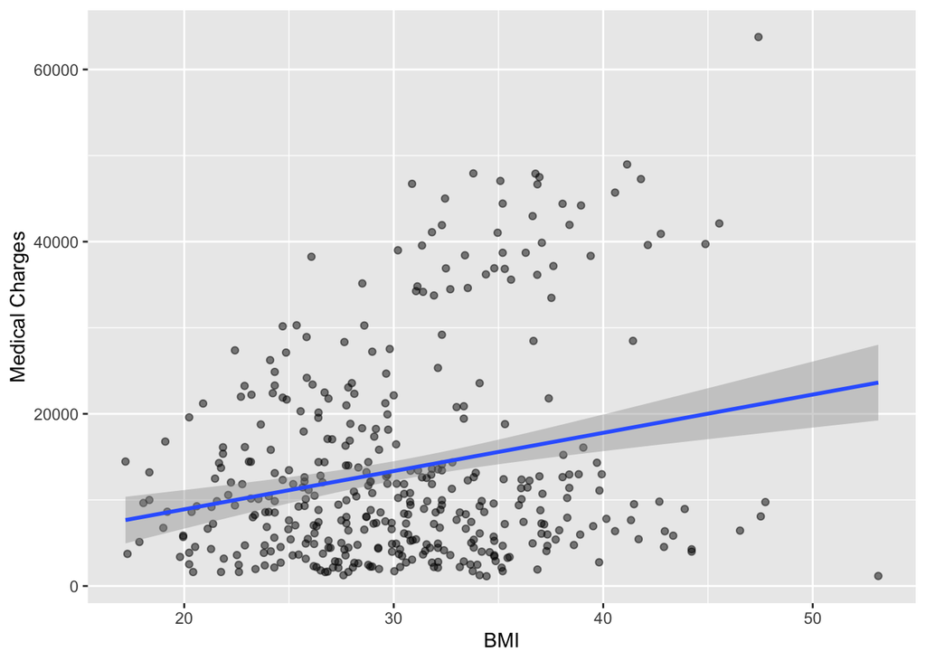

```r
ggplot(test_strat, aes(x = bmi, y = charges)) +
  geom_point(alpha = 0.5) +
  geom_smooth(method = "lm", level = 0.95) +
  labs( x = "BMI",
       y = "Medical Charges")
```

10. Predict the expected medical charges when a policyholder has bmi at 30 using the estimated simple linear regression model.

```r
predict(model_SL, newdata = data.frame(bmi = 30))
```

```
       1
12884.16
```

11. Print out the model using `stargazer` package.

```r
library(stargazer)
stargazer(model_SL,
          type = "text",
          title = "Simple Linear Regression Results",
          dep.var.labels = "Medical Charges",
          covariate.labels = "BMI",
          digits = 3)
```

```
Simple Linear Regression Results
===============================================
                        Dependent variable:
                    ---------------------------
                          Medical Charges
-----------------------------------------------
BMI                         373.744***
                             (64.399)

Constant                     1,671.848
                            (2,021.606)

-----------------------------------------------
Observations                    937
R2                             0.035
Adjusted R2                    0.034
Residual Std. Error    11,984.890 (df = 935)
F Statistic           33.681*** (df = 1; 935)
===============================================
Note:               *p<0.1; **p<0.05; ***p<0.01
```